# Home Values After Transit Line

## Measuring the Impact of Transit on Housing Prices

Local officials have claimed that a new light rail line has increased property values in a local neighborhood.

Before the transit line opened, homes in that neighborhood sold for an average of $285,000, with a standard deviation of $32,000.

Since the extension opened, your news team collected sales data from 14 recent home sales in the neighborhood: $297,000, $305,000, $292,000, $318,000, $290,000, $311,000, $299,000, $325,000, $302,000, $288,000, $307,000, $315,000, $320,000, $294,000

As a journalist, you need to determine: **Is there statistical evidence that the transit line has actually increased home values?**

Follow along, running the code when directed. If you have questions, ask either in class or put them just below the section you have a question about.

## Task 1: Organize your data

```r
# Known information about home values before the transit line
prior_mean <- 285000  # average home value
prior_sd <- 32000     # standard deviation

# Home sale prices after the transit line opened (14 homes)
new_prices <- c(297000, 305000, 292000, 318000, 290000, 311000, 299000,
                325000, 302000, 288000, 307000, 315000, 320000, 294000)

# Create a journalist-friendly dataset
home_data <- tibble(
  sale_id = 1:14,
  sale_price = new_prices
)

# View the data
home_data
```

```
## # A tibble: 14 × 2
##    sale_id sale_price
##      <int>      <dbl>
##  1       1     297000
##  2       2     305000
##  3       3     292000
##  4       4     318000
##  5       5     290000
##  6       6     311000
##  7       7     299000
##  8       8     325000
##  9       9     302000
## 10      10     288000
## 11      11     307000
## 12      12     315000
## 13      13     320000
## 14      14     294000
```

## Task 2: Calculate key statistics

```r
# Calculate statistics on the new home price data
new_stats <- home_data |>
  summarise(
    mean = mean(sale_price),
    sd = sd(sale_price),
    n = n(),
    min = min(sale_price),
    max = max(sale_price)
  )

new_stats
```

```
## # A tibble: 1 × 5
##     mean     sd     n    min    max
##    <dbl>  <dbl> <int>  <dbl>  <dbl>
## 1 304500 11908.    14 288000 325000
```

## Task 3: Make a chart

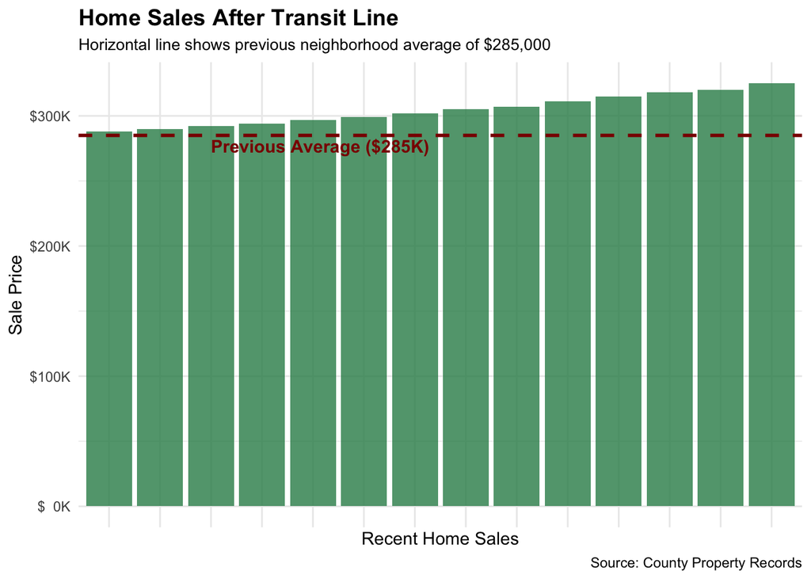

```r
# Function to format currency values
dollar_format <- function(x) {
  paste0("$", format(x/1000, big.mark=","), "K")
}

# Create a visualization of home prices with reference to previous average
ggplot(home_data, aes(x = reorder(sale_id, sale_price), y = sale_price)) +
  geom_col(fill = "seagreen", alpha = 0.8) +
  geom_hline(yintercept = prior_mean, color = "darkred", size = 1, linetype = "dashed") +
  annotate("text", x = 3, y = prior_mean - 8000,
           label = "Previous Average ($285K)", hjust = 0, fontface = "bold", color = "darkred") +
  scale_y_continuous(labels = dollar_format) +
  labs(
    title = "Home Sales After Transit Line",
    subtitle = "Horizontal line shows previous neighborhood average of $285,000",
    x = "Recent Home Sales",
    y = "Sale Price",
    caption = "Source: County Property Records"
  ) +
  theme_minimal() +
  theme(
    plot.title = element_text(face = "bold", size = 14),
    plot.subtitle = element_text(size = 10),
    axis.text.x = element_blank(),
    axis.ticks.x = element_blank()
  )
```

## Task 4: Perform a hypothesis test

This is where we formally test the officials’ claim that the transit line has increased home values.

**Hypotheses:** - H₀: μ ≤ $285,000 (The transit line has not increased home values) - H₁: μ > $285,000 (The transit line has increased home values)

```r
# Perform a one-sample t-test
# Since we want to know if home values increased, we use a one-sided test (alternative = "greater")
t_test_result <- t.test(
  home_data$sale_price,
  mu = prior_mean,
  alternative = "greater"
)

# Display the results
t_test_result
```

```
##
##  One Sample t-test
##
## data:  home_data$sale_price
## t = 6.127, df = 13, p-value = 0.0000181
## alternative hypothesis: true mean is greater than 285000
## 95 percent confidence interval:
##  298863.8      Inf
## sample estimates:
## mean of x
##    304500
```

## Task 5: Interpreting the results for your story

```r
# Extract the p-value
p_value <- t_test_result$p.value

# Calculate the 95% confidence interval
ci <- t.test(home_data$sale_price)$conf.int

# Format and display the confidence interval in a readable way
ci_formatted <- tibble(
  `Lower bound` = dollar_format(ci[1]),
  `Upper bound` = dollar_format(ci[2]),
  `Confidence level` = "95%"
)

# Display as a nice table
ci_formatted
```

```
## # A tibble: 1 × 3
##   `Lower bound` `Upper bound` `Confidence level`
##   <chr>         <chr>         <chr>
## 1 $297.6244K    $311.3756K    95%
```

```r
# Set our significance level
alpha <- 0.05

# Compare and make a decision
if(p_value < alpha) {
  conclusion <- "The data provides statistical evidence supporting the claim that the transit line has increased home values."
} else {
  conclusion <- "The data does not provide strong statistical evidence that the transit line has increased home values."
}

# Create a tibble to display the key statistics for your story
story_stats <- tibble(
  `Previous average` = dollar_format(prior_mean),
  `New average` = dollar_format(mean(new_prices)),
  `Increase` = dollar_format(mean(new_prices) - prior_mean),
  `Percent change` = paste0(round(((mean(new_prices) - prior_mean) / prior_mean) * 100, 1), "%"),
  `p-value` = p_value,
  `Statistically significant?` = if_else(p_value < alpha, "Yes", "No")
)

# Display the key statistics
story_stats
```

```
## # A tibble: 1 × 6
##   `Previous average` `New average` Increase `Percent change` `p-value`
##   <chr>              <chr>         <chr>    <chr>                <dbl>
## 1 $285K              $304.5K       $19.5K   6.8%             0.0000181
## # ℹ 1 more variable: `Statistically significant?` <chr>
```

```r
print(conclusion)
```

```
## [1] "The data provides statistical evidence supporting the claim that the transit line has increased home values."
```

## Task 6: What’s the story?

After discussion the results, each person writes a couple of sentences for the top of a story about local officials’ claims on the impact of the transit line and what the data says. Remember that there are lots of possible reasons that could influence the price of a home. Make your sentences newsy.

A new light rail extension may be raising home values in a local neighborhood, with recent sales averaging about nearly $20,000 higher than before the line opened. New data has provided statistical evidence to support the claim that the transit line has increased prices. Still, although statistically significant, housing markets are influenced by a variety of factors and we cannot rely on data alone to prove the rail line is the main cause.